# EXPLORATORY DATA ANALYSIS ON WHITE WINE DATASET BY SHRISHTI

### INTRODUCTION OF DATA SET

White wine is a wine whose colour can be straw-yellow, yellow-green, or yellow-gold. It is produced by the alcoholic fermentation of the non-coloured pulp of grapes, which may have a skin of any colour.

[figure not shown]

### OBJECTIVE

The project is aimed at looking and finding deep insights of the white wine dataset.The purpose of this project is to determine what physical and chemical properties affect white wine quality through exploratory data analysis of a dataset containing 4898 white variants of the portuguese "vinho verde" wine.

Due to privacy and logistic issues only physical and chemical inputs are available.

### DATA DESCRIPTION

The white wine dataset have all physical and chemical input variables which effects quality of wine.The dataset have 12 variables,11 of are pyhsical and chemical properties and other input variable is of quality. All chemical properties data are continuous variable. Quality is an oridinal variable with possible rankings from 1(worst) to 10(best).

Dataset have 4898 rows and 12 columns respectively. The total number of values in dataset are 58776.

Different samples of white wine are tasted by differnt consumers and final rating is assigned to wine sample.

### ATTRIBUTE INFORMATION

Following variables are present in dataset which have to be analysed

1. fixed acidity
2. volatile acidity
3. citric acid
4. Residual sugar
5. chlorides
6. free sulphur dioxide
7. total sulphur dioxide
8. density
9. pH
10. sulphates
11. alcohol
12. quality

##### Importing all libraries needed for exploratory data analysis

Following libraries are required:

1. pandas (data manupilation and handling)
2. numpy ( calculating mean meadian etc for dataset)
3. matplotlib.pyplot ( visualization)
4. seaborn (visulaization)

```python
from IPython.display import HTML

HTML('''<script>
code_show=true;
function code_toggle() {
 if (code_show){
 $('div.input').hide();
 } else {
 $('div.input').show();
 }
 code_show = !code_show
}
$( document ).ready(code_toggle);
</script>
<form action="javascript:code_toggle()"><input type="submit" value="Click here to toggle on/off the raw code."></form>''')
```

```python
import pandas as pd
import numpy as np
import matplotlib.pyplot as plt
import seaborn as sns
%matplotlib inline
```

#### Importing dataset of white wine

```python
df=pd.read_csv("E:\winequality-white.csv")
```

#### Printing first five rows of dataset using head function

```python
print("First five rows of dataset")
df.head()
```

```
First five rows of dataset
```

|  | fixed acidity | volatile acidity | citric acid | residual sugar | chlorides | free sulfur dioxide | total sulfur dioxide | density | pH | sulphates | alcohol | quality |
| --- | --- | --- | --- | --- | --- | --- | --- | --- | --- | --- | --- | --- |
| 0 | 7.0 | 0.27 | 0.36 | 20.7 | 0.045 | 45.0 | 170.0 | 1.0010 | 3.00 | 0.45 | 8.8 | 6 |
| 1 | 6.3 | 0.30 | 0.34 | 1.6 | 0.049 | 14.0 | 132.0 | 0.9940 | 3.30 | 0.49 | 9.5 | 6 |
| 2 | 8.1 | 0.28 | 0.40 | 6.9 | 0.050 | 30.0 | 97.0 | 0.9951 | 3.26 | 0.44 | 10.1 | 6 |
| 3 | 7.2 | 0.23 | 0.32 | 8.5 | 0.058 | 47.0 | 186.0 | 0.9956 | 3.19 | 0.40 | 9.9 | 6 |
| 4 | 7.2 | 0.23 | 0.32 | 8.5 | 0.058 | 47.0 | 186.0 | 0.9956 | 3.19 | 0.40 | 9.9 | 6 |

#### Shape of dataset: 4898 rows and 12 columns

```python
print("Shape of white wine dataset")
df.shape
```

```
Shape of white wine dataset
```

```
(4898, 12)
```

#### size of dataset i.e. total number of values in dataset are 58776

```python
print("Size of dataset:")
df.size
```

```
Size of dataset:
```

```
58776
```

#### Describing all the statistical parameters for dataset using describe function like count,mean,std,min max etc.

```python
print("Statistical parameters for data set are:")
df.describe()
```

```
Statistical parameters for data set are:
```

|  | fixed acidity | volatile acidity | citric acid | residual sugar | chlorides | free sulfur dioxide | total sulfur dioxide | density | pH | sulphates | alcohol | quality |
| --- | --- | --- | --- | --- | --- | --- | --- | --- | --- | --- | --- | --- |
| count | 4898.000000 | 4898.000000 | 4898.000000 | 4898.000000 | 4898.000000 | 4898.000000 | 4898.000000 | 4898.000000 | 4898.000000 | 4898.000000 | 4898.000000 | 4898.000000 |
| mean | 6.854788 | 0.278241 | 0.334192 | 6.391415 | 0.045772 | 35.308085 | 138.360657 | 0.994027 | 3.188267 | 0.489847 | 10.514267 | 5.877909 |
| std | 0.843868 | 0.100795 | 0.121020 | 5.072058 | 0.021848 | 17.007137 | 42.498065 | 0.002991 | 0.151001 | 0.114126 | 1.230621 | 0.885639 |
| min | 3.800000 | 0.080000 | 0.000000 | 0.600000 | 0.009000 | 2.000000 | 9.000000 | 0.987110 | 2.720000 | 0.220000 | 8.000000 | 3.000000 |
| 25% | 6.300000 | 0.210000 | 0.270000 | 1.700000 | 0.036000 | 23.000000 | 108.000000 | 0.991723 | 3.090000 | 0.410000 | 9.500000 | 5.000000 |
| 50% | 6.800000 | 0.260000 | 0.320000 | 5.200000 | 0.043000 | 34.000000 | 134.000000 | 0.993740 | 3.180000 | 0.470000 | 10.400000 | 6.000000 |
| 75% | 7.300000 | 0.320000 | 0.390000 | 9.900000 | 0.050000 | 46.000000 | 167.000000 | 0.996100 | 3.280000 | 0.550000 | 11.400000 | 6.000000 |
| max | 14.200000 | 1.100000 | 1.660000 | 65.800000 | 0.346000 | 289.000000 | 440.000000 | 1.038980 | 3.820000 | 1.080000 | 14.200000 | 9.000000 |

Following code checks for null values in dataset.

The dataset have no null values i.e. data is clean.

```python
print("Checking for null values")
df.isnull().sum()
```

```
Checking for null values
```

```
fixed acidity           0
volatile acidity        0
citric acid             0
residual sugar          0
chlorides               0
free sulfur dioxide     0
total sulfur dioxide    0
density                 0
pH                      0
sulphates               0
alcohol                 0
quality                 0
dtype: int64
```

## UNIVARIATE ANALYSIS:

Univariate is simplest way of analyzing data.'Uni' means one implies that we only analyze one variable at a time. Univariate plots gives us the ideas of present outlliers in data and it also helps in bivariate and multivariate analysis. Plots like barplot,histogram,boxplot,distribution plot etc are generally used for univariate analysis.

Barplot are generally plot for oridinal data and histrogram ,distribution etc are plot for continuous data variables.

### FIXED ACIDITY - COUNT PLOT

Here's the fixed acidity countplot. As fixed acidity data variable is continous in nature so we plot histogram to see the distribution.

```
Text(0.5,1,'FIXED ACIDITY COUNTPLOT')
```

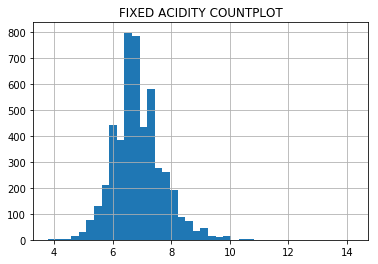

```python
plt.hist(x="fixed acidity",data=df,bins=40)
plt.grid()
plt.title("FIXED ACIDITY COUNTPLOT")
```

Following trends are observed from above fixed acidity countplot

1. It follows normal distribution
2. Most wine sample have fixed acidity level in range 6%-8% g/dm^3.
3. Few points seems to be outliers

### VOLATILE ACIDITY - COUNTPLOT

Here's the volatile acidity count plot. As volatile acidity is continous data varible so here we plot histgram for volatile acidity.

[output not shown]

[figure not shown]

```python
plt.hist(x="volatile acidity",data= df,bins=30)
plt.grid()
plt.title("VOLATILE ACIDITY COUNTPLOT")
```

Following ternds can be observed from above data:

1. Many outliers are present
2. The distribution is skewed
3. Maximum number of wine bottles have volatile acidity in b/w 0.2%-0.4%(g/dm^3)

### CITRIC ACID - COUNTPLOT

```
Text(0.5,1,'CITRIC ACID COUNTPLOT')
```

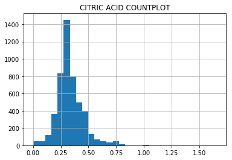

```python
plt.hist(x="citric acid",data= df,bins=30)
plt.grid()
plt.title("CITRIC ACID COUNTPLOT")
```

Following ternds can be observed form above citric acid coutplot graph:

1. It shows normal distribution
2. Few outliers are present
3. Most wine samples have concent of citric acid b/w 0.25%-0.50%(g/dm^3)

### RESIDUAL SUGAR - COUNT PLOT

Hers's countplot of residual sugar.Disrtribution graph is plot to see the distribution of residual sugar.

```
Text(0.5,1,'RESIDUAL SUGAR COUNT PLOT')
```

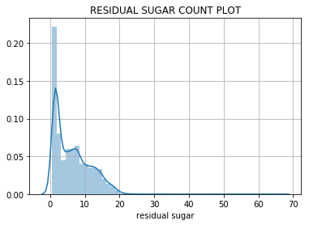

```python
sns.distplot(df['residual sugar'])
plt.grid()
plt.title("RESIDUAL SUGAR COUNT PLOT")
```

Follwing trends can be observed by above residual sugar plot:

1. The distributio is skewed
2. Most samples have concent of residual sugar less than 10%(g/dm^3)

### CHLORIDES - COUNTPLOT

Here's countplot of chloride.As data variable is continous ,histogram plot is used to see trends in chlorides.

```
Text(0.5,1,'CHLORIDES COUNTPLOT')
```

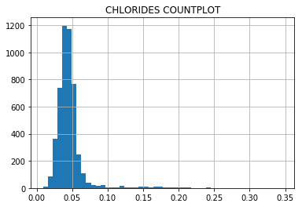

```python
plt.hist(x="chlorides",data=df,bins=50)
plt.grid()
plt.title("CHLORIDES COUNTPLOT")
```

Following trends are observed from above chlorides plot:

1. The distribution is skewed
2. There seems to be many number of outliers
3. Most wine samples have less concentration of chloride
4. Most wine sample have chloride content less than 0.1%(g/dm^3).

### FREE SULPHUR DIOXIDE - COUNTPLOT

```
Text(0.5,1,'BOXPLOT OF FREE SULPHUR DIOXIDE')
```

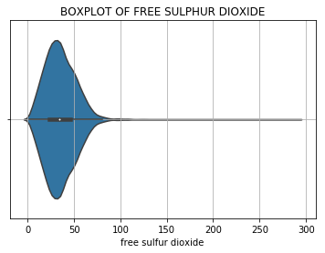

```python
sns.violinplot(df['free sulfur dioxide'])
plt.grid()
plt.title("BOXPLOT OF FREE SULPHUR DIOXIDE")
```

### DENSITY - COUNTPLOT

Here's countplot of density data varible.We can see the trends in density usinf histogram plot.

```
Text(0.5,1,'DENSITY COUNT PLOT')
```

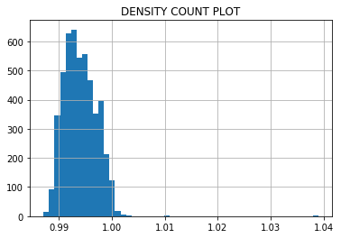

```python
plt.hist(x="density",data=df,bins=50)
plt.grid()
plt.title("DENSITY COUNT PLOT")
```

Following trends are observed from above plot.

1. It shows normal distribution
2. Few points appeared to be outliers
3. Most white wine sample have density in range of 0.99-1.00 g/cm3

### pH - COUNTPLOT

Here's countplot of pH.

```
Text(0.5,1,'pH COUNT PLOT')
```

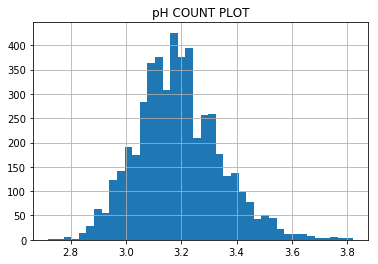

```python
plt.hist(x="pH",data=df,bins=40)
plt.grid()
plt.title("pH COUNT PLOT")
```

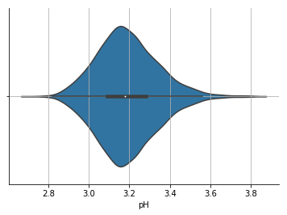

```python
sns.violinplot(df['pH'])
sns.despine()
plt.grid()
```

Following trends are observed form above plot.

1. Few points seems to be minor outliers
2. Maximmum wine samples have pH B/w 3.1-3.3

### TOTAL SULFUR DIOXIDE - COUNTPLOT

Here's countplot of total sulphur dioxide

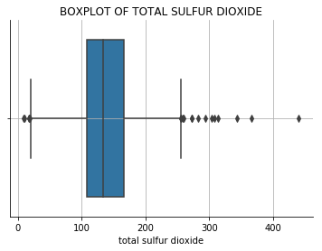

```python
sns.boxplot(df['total sulfur dioxide'])
plt.grid()
plt.title("BOXPLOT OF TOTAL SULFUR DIOXIDE")
sns.despine()
```

Following findings can be observed from above plot:

1. Few points seems to be an outlier
2. Most of wine have total sulfur dioxide content b/w 100-200 mg/dm^3

### SULPHATES - COUNTPLOT

Here's countplot of sulphates

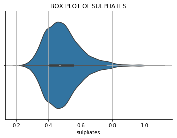

```python
sns.violinplot(df['sulphates'])
plt.grid()
plt.title("BOX PLOT OF SULPHATES")
sns.despine()
```

### ALCOHOL - COUNTPLOT

Here's the count plot of alcohol.

```
Text(0.5,1,'ALCOHOL COUNTPLOT')
```

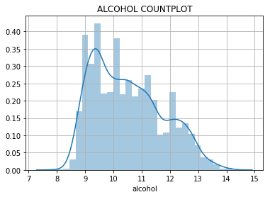

```python
sns.distplot(df['alcohol'])
plt.grid()
plt.title("ALCOHOL COUNTPLOT")
```

### QUALITY - COUNTPLOT

Here's quality count plot. As the quality is oridinal data variable , bar plot i used to se the distribution.

```
Text(0.5,1,'BARPLOT OF QUALITY')
```

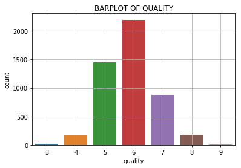

```python
sns.countplot(x='quality',data=df)
plt.grid()
plt.title("BARPLOT OF QUALITY")
```

Following trends are observed from above quality count plot.

1. The quality rating 5 and 6 are hign in number.
2. Few number of wines have higher rating than 7 and less numbr of wines have rating 3
3. Most wine samples have mediocre quality

## BIVARIATE ANALYSIS

Bivariate analysis is one of the simplest forms of statistical analysis. it involves the analysis of two variables(often denoted as X,Y) for the purpose to determine the relationship b/w different quantities.

#### 'Correlation' refers to a mutual relationship or association b/w differnt quantites.

Here we calculate correlation i.e statistical parameter of dataset which gives us relatioship b/w differnt quantities.

```python
df.corr()
```

|  | fixed acidity | volatile acidity | citric acid | residual sugar | chlorides | free sulfur dioxide | total sulfur dioxide | density | pH | sulphates | alcohol | quality |
| --- | --- | --- | --- | --- | --- | --- | --- | --- | --- | --- | --- | --- |
| fixed acidity | 1.000000 | -0.022697 | 0.289181 | 0.089021 | 0.023086 | -0.049396 | 0.091070 | 0.265331 | -0.425858 | -0.017143 | -0.120881 | -0.113663 |
| volatile acidity | -0.022697 | 1.000000 | -0.149472 | 0.064286 | 0.070512 | -0.097012 | 0.089261 | 0.027114 | -0.031915 | -0.035728 | 0.067718 | -0.194723 |
| citric acid | 0.289181 | -0.149472 | 1.000000 | 0.094212 | 0.114364 | 0.094077 | 0.121131 | 0.149503 | -0.163748 | 0.062331 | -0.075729 | -0.009209 |
| residual sugar | 0.089021 | 0.064286 | 0.094212 | 1.000000 | 0.088685 | 0.299098 | 0.401439 | 0.838966 | -0.194133 | -0.026664 | -0.450631 | -0.097577 |
| chlorides | 0.023086 | 0.070512 | 0.114364 | 0.088685 | 1.000000 | 0.101392 | 0.198910 | 0.257211 | -0.090439 | 0.016763 | -0.360189 | -0.209934 |
| free sulfur dioxide | -0.049396 | -0.097012 | 0.094077 | 0.299098 | 0.101392 | 1.000000 | 0.615501 | 0.294210 | -0.000618 | 0.059217 | -0.250104 | 0.008158 |
| total sulfur dioxide | 0.091070 | 0.089261 | 0.121131 | 0.401439 | 0.198910 | 0.615501 | 1.000000 | 0.529881 | 0.002321 | 0.134562 | -0.448892 | -0.174737 |
| density | 0.265331 | 0.027114 | 0.149503 | 0.838966 | 0.257211 | 0.294210 | 0.529881 | 1.000000 | -0.093591 | 0.074493 | -0.780138 | -0.307123 |
| pH | -0.425858 | -0.031915 | -0.163748 | -0.194133 | -0.090439 | -0.000618 | 0.002321 | -0.093591 | 1.000000 | 0.155951 | 0.121432 | 0.099427 |
| sulphates | -0.017143 | -0.035728 | 0.062331 | -0.026664 | 0.016763 | 0.059217 | 0.134562 | 0.074493 | 0.155951 | 1.000000 | -0.017433 | 0.053678 |
| alcohol | -0.120881 | 0.067718 | -0.075729 | -0.450631 | -0.360189 | -0.250104 | -0.448892 | -0.780138 | 0.121432 | -0.017433 | 1.000000 | 0.435575 |
| quality | -0.113663 | -0.194723 | -0.009209 | -0.097577 | -0.209934 | 0.008158 | -0.174737 | -0.307123 | 0.099427 | 0.053678 | 0.435575 | 1.000000 |

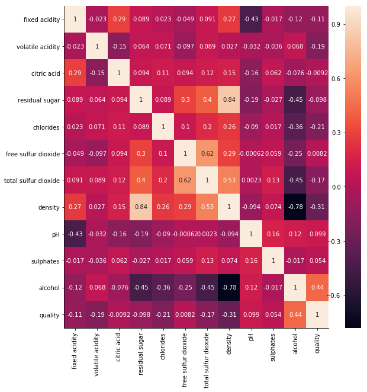

```python
plt.figure(figsize=(10,10))
sns.heatmap(df.corr(),annot=True)
sns.despine()
```

### ALCOHOL Vs QUALITY PLOT

Here's jitter plot for alcohol Vs quality.

```
Text(0.5,1,'ALCOHOL Vs QUALITY PLOT')
```

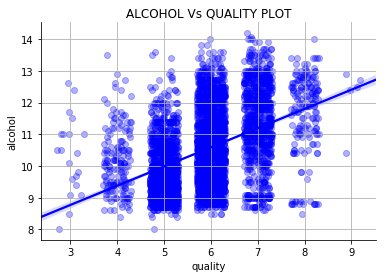

```python
sns.regplot(x='quality',y='alcohol',data=df,x_jitter=0.3,scatter_kws={'alpha':0.3},color="blue")
sns.despine()
plt.grid()
plt.title("ALCOHOL Vs QUALITY PLOT")
```

Following trends are observed from above alcohol Vs quality plot:

1. Alcohol and quality have correlation coefficient of 0.44
2. Above plot shows increasing trend b/w alcohol and quality i.e.better quality wines have more alcohol content
3. We can observe that mediocre quality wines i.e of quality (5 and 6) have alcohol content 9%-12% and 9%-14% by volume respectively

### ALCOHOL Vs DENSITY PLOT

Here's is jitter plot for Alcohol Vs density.

```
Text(0.5,1,'ALCOHOL Vs DENSITY PLOT')
```

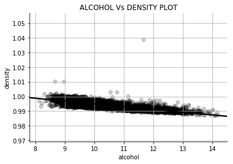

```python
sns.regplot(x='alcohol',y='density',data=df,x_jitter=0.2,scatter_kws={'alpha':0.2},color="black")
sns.despine()
plt.grid()
plt.title("ALCOHOL Vs DENSITY PLOT")
```

Following trends are observed from above Alcohol vs density plot:

1. Alcohol and density have correlation coefficient of -0.78
2. Above plot shows decreasing trend b/w alcohol and density plot
3. Density decreses of white wine with increase in alcoholic content
4. One outlier is present b/w 11-12% which have high density.

### QUALITY Vs DENSITY PLOT

Here's boxplot for quality Vs density plot

```
Text(0.5,1,'QUALITY Vs DENSITY PLOT')
```

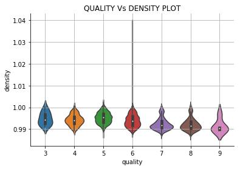

```python
sns.violinplot(x='quality',y='density',data=df)
plt.grid()
sns.despine()
plt.title("QUALITY Vs DENSITY PLOT")
```

1. Quality and density have correlation coefficient of -0.31
2. Most wine samples have density in range of 0.99%-1.00%(g/dm^3)

### ALCOHOL Vs RESIDUAL SUGAR

Here's jitter plot for alcohol Vs residual sugar

```
Text(0.5,1,'ALCOHOL Vs RESIDUAL SUGAR PLOT')
```

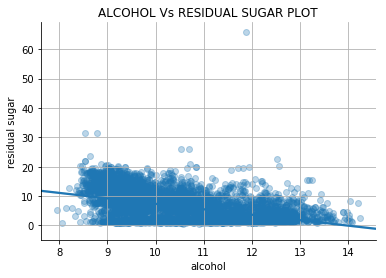

```python
sns.regplot(x='alcohol',y='residual sugar',data=df,x_jitter=0.3,scatter_kws={'alpha':0.3})
sns.despine()
plt.grid()
plt.title("ALCOHOL Vs RESIDUAL SUGAR PLOT")
```

Following trends can be observed from above plot:

1. Alcohol and residual sugar have correlation coefficient of -0.45
2. Above plot shows slight decresing trend b/w alcohol Vs residual sugar
3. From above we can observed that the samples having high reisdual sugar content contain less alcohol content.
4. Few samples might have high content of residual sugar inspite of low alcohol content. These points are out of trends and behave as outliers.

### FREE SULPHUR DIOXIDE Vs TOTAL SULPHUR DIOXIDE PLOT

Here's plot for free sulphur dioxide Vs total sulphur dioxide

```
Text(0.5,1,'FREE SULPHUR DIOXIDE Vs TOTAL SULPHUR DIOXIDE PLOT')
```

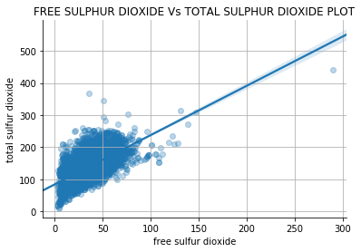

```python
sns.regplot(x='free sulfur dioxide' ,y='total sulfur dioxide',data=df,x_jitter=0.3,scatter_kws={'alpha':0.3})
sns.despine()
plt.grid()
plt.title("FREE SULPHUR DIOXIDE Vs TOTAL SULPHUR DIOXIDE PLOT")
```

Following trends can be observed from above plot:

1. Free sulfur dioxide and total sulphur dioxide have correlation coefficient of 0.62
2. Above plot shows incresing trend b/w total sulphur dioxide Vs free sulfur dioxide i..e. the increase in content of total sulphur dioxide in wine sample increases content of free sulphur diaoxide.
3. Most Wine samples have more amount of total sulfur dioxide relative to free sulphur dioxide.

### pH Vs FIXED ACIDITY PLOT

Here's plot for pH Vs fixed acidity

```
Text(0.5,1,'pH Vs FIXED ACIDITY PLOT')
```

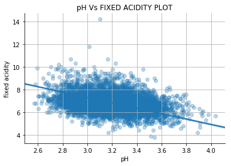

```python
sns.regplot(x='pH',y='fixed acidity',data=df,x_jitter=0.3,scatter_kws={'alpha':0.3})
sns.despine()
plt.grid()
plt.title("pH Vs FIXED ACIDITY PLOT")
```

### DENSITY Vs RESIDUAL SUGAR PLOT

Here's jitter plot of Density Vs residual sugar

```
Text(0.5,1,'DENSITY Vs RESIDUAL SUGAR PLOT')
```

[figure not shown]

```python
sns.regplot(x='density',y='residual sugar',data=df,x_jitter=0.3,scatter_kws={'alpha':0.3})
sns.despine()
plt.grid()
plt.title("DENSITY Vs RESIDUAL SUGAR PLOT")
```

Folowing trends can be observed from above plot:

1. Correlation coeficient of density and residual sugar is 0.84 which is high.

### MULTIVARIATE ANALYSIS

Multivariate data analysisn refers to any statistical technique used to analyze data that arises from more than one variable,and this techniques are very valuable when working with correlated variables.

### ALCOHOL Vs DENSITY PLOT IN TERMS OF QUALITY PLOT

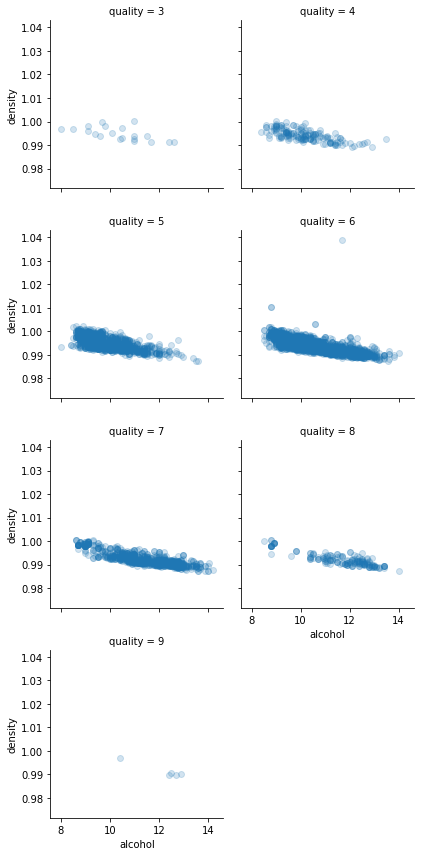

```python
grid = sns.FacetGrid(df, col='quality',col_wrap=2)
grid.map(plt.scatter,'alcohol','density',alpha = 0.2)
sns.despine()
```

##### Inferences from above plot

From the above facet plots ,we observed that the as the quality of wines depend both factors alcohol as well as density,however better qualty wine have more alcoholic content but density loks like same i.e. its does not show any major change.

### ALCOHOL Vs RESIDUAL SUGAR PLOT IN TERMS OF QUALITY

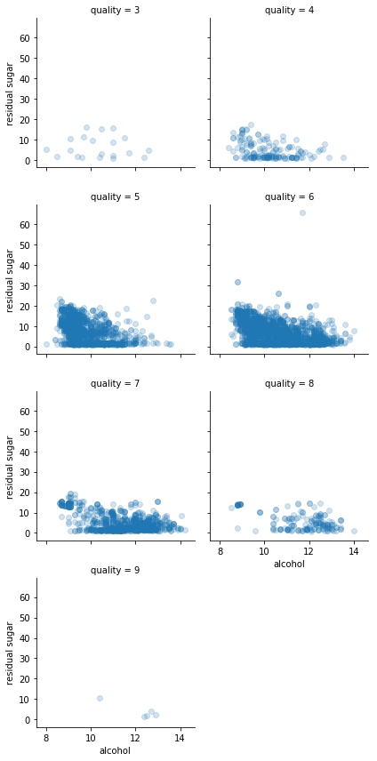

```python
grid = sns.FacetGrid(df, col='quality',col_wrap=2)
grid.map(plt.scatter,'alcohol','residual sugar',alpha = 0.2)
```

### pH Vs FIXED ACIDITY PLOT IN TERMS OF QUALITY

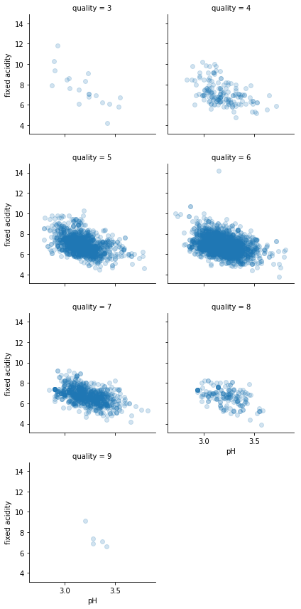

```python
grid = sns.FacetGrid(df, col='quality',col_wrap=2)
grid.map(plt.scatter,'pH','fixed acidity',alpha = 0.2)
sns.despine()
```

#### Inferences from above plot:

1. From the above facet,we observed that with increase in quality of wine content of fixed acidiyt shows desresing trending while pH does not show any major changes .

## FINAL PLOT SELECTION

### ALCOHOL Vs QUALITY PLOT

As our main aim is to find physical and chemical properties in which a little change effect quality of wine,so as from heatmap plot we notice that quality and alcohol have correlation coefficient of 0.44 which is good.We also observe high quality wine have more alcohol content so that's why alcohol Vs quality plays significant role in making good quality wine.

```
Text(0.5,1,'ALCOHOL Vs QUALITY PLOT')
```

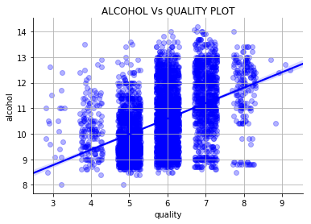

```python
sns.regplot(x='quality',y='alcohol',data=df,x_jitter=0.3,scatter_kws={'alpha':0.3},color="blue")
sns.despine()
plt.grid()
plt.title("ALCOHOL Vs QUALITY PLOT")
```

Following trends are observed from above alcohol Vs quality plot:

1. Alcohol and quality have correlation coefficient of 0.44
2. Above plot shows increasing trend b/w alcohol and quality i.e.better quality wines have more alcohol content
3. We can observe that mediocre quality wines i.e of quality (5 and 6) have alcohol content 9%-12% and 9%-14% by volume respectively

### pH Vs FIXED ACIDITY PLOT IN TERMS OF QUALITY

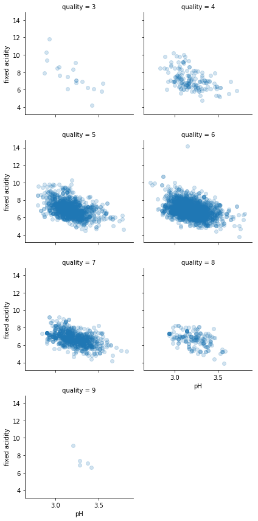

```python
grid = sns.FacetGrid(df, col='quality',col_wrap=2)
grid.map(plt.scatter,'pH','fixed acidity',alpha = 0.2)
sns.despine()
```

#### Inferences from above plot:

1. From the above facet,we observed that with increase in quality of wine content of fixed acidiyt shows desresing trending while pH does not show any major changes .

### FREE SULPHUR DIOXIDE Vs TOTAL SULPHUR DIOXIDE

```
Text(0.5,1,'FREE SULPHUR DIOXIDE Vs TOTAL SULPHUR DIOXIDE PLOT')
```

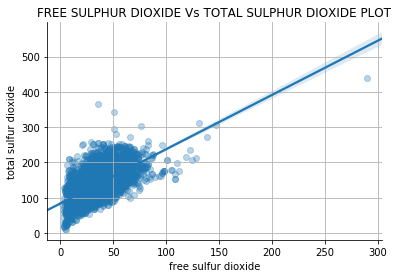

```python
sns.regplot(x='free sulfur dioxide' ,y='total sulfur dioxide',data=df,x_jitter=0.3,scatter_kws={'alpha':0.3})
sns.despine()
plt.grid()
plt.title("FREE SULPHUR DIOXIDE Vs TOTAL SULPHUR DIOXIDE PLOT")
```

Following trends can be observed from above plot:

1. Free sulfur dioxide and total sulphur dioxide have correlation coefficient of 0.62
2. Above plot shows incresing trend b/w total sulphur dioxide Vs free sulfur dioxide i..e. the increase in content of total sulphur dioxide in wine sample increases content of free sulphur diaoxide.
3. Most Wine samples have more amount of total sulfur dioxide relative to free sulphur dioxide.